# TidyVerse CREATE: Exploring College Major Earnings with dplyr, ggplot2, and tidyr

## Introduction

This vignette demonstrates core capabilities of three TidyVerse packages: **dplyr**, **ggplot2**, and **tidyr**, using the `college_recent_grads` dataset from the `fivethirtyeight` package.

Note: to install fivethirtyeight in the console: `install.packages("fivethirtyeight")`

## Load Libraries and Data

```r
library(tidyverse)
library(fivethirtyeight)

data("college_recent_grads")
glimpse(college_recent_grads)
```

```
## Rows: 173
## Columns: 21
## $ rank                        <int> 1, 2, 3, 4, 5, 6, 7, 8, 9, 10, 11, 12, 13,…
## $ major_code                  <int> 2419, 2416, 2415, 2417, 2405, 2418, 6202, …
## $ major                       <chr> "Petroleum Engineering", "Mining And Miner…
## $ major_category              <chr> "Engineering", "Engineering", "Engineering…
## $ total                       <int> 2339, 756, 856, 1258, 32260, 2573, 3777, 1…
## $ sample_size                 <int> 36, 7, 3, 16, 289, 17, 51, 10, 1029, 631, …
## $ men                         <int> 2057, 679, 725, 1123, 21239, 2200, 2110, 8…
## $ women                       <int> 282, 77, 131, 135, 11021, 373, 1667, 960, …
## $ sharewomen                  <dbl> 0.1205643, 0.1018519, 0.1530374, 0.1073132…
## $ employed                    <int> 1976, 640, 648, 758, 25694, 1857, 2912, 15…
## $ employed_fulltime           <int> 1849, 556, 558, 1069, 23170, 2038, 2924, 1…
## $ employed_parttime           <int> 270, 170, 133, 150, 5180, 264, 296, 553, 1…
## $ employed_fulltime_yearround <int> 1207, 388, 340, 692, 16697, 1449, 2482, 82…
## $ unemployed                  <int> 37, 85, 16, 40, 1672, 400, 308, 33, 4650, …
## $ unemployment_rate           <dbl> 0.018380527, 0.117241379, 0.024096386, 0.0…
## $ p25th                       <dbl> 95000, 55000, 50000, 43000, 50000, 50000, …
## $ median                      <dbl> 110000, 75000, 73000, 70000, 65000, 65000,…
## $ p75th                       <dbl> 125000, 90000, 105000, 80000, 75000, 10200…
## $ college_jobs                <int> 1534, 350, 456, 529, 18314, 1142, 1768, 97…
## $ non_college_jobs            <int> 364, 257, 176, 102, 4440, 657, 314, 500, 1…
## $ low_wage_jobs               <int> 193, 50, 0, 0, 972, 244, 259, 220, 3253, 3…
```

## Part 1: dplyr – Selecting, Filtering, and Summarizing

### select() – Pick the columns you need

`select()` lets you keep only the columns relevant to your analysis, which makes data frames easier to read and work with.

```r
major_earnings <- college_recent_grads |>
  select(major, major_category, total, median, p25th, p75th, unemployment_rate)

head(major_earnings)
```

```
## # A tibble: 6 × 7
##   major               major_category total median p25th  p75th unemployment_rate
##   <chr>               <chr>          <int>  <dbl> <dbl>  <dbl>             <dbl>
## 1 Petroleum Engineer… Engineering     2339 110000 95000 125000            0.0184
## 2 Mining And Mineral… Engineering      756  75000 55000  90000            0.117
## 3 Metallurgical Engi… Engineering      856  73000 50000 105000            0.0241
## 4 Naval Architecture… Engineering     1258  70000 43000  80000            0.0501
## 5 Chemical Engineeri… Engineering    32260  65000 50000  75000            0.0611
## 6 Nuclear Engineering Engineering     2573  65000 50000 102000            0.177
```

### filter() – Subset rows by condition

`filter()` keeps only the rows that satisfy a logical condition. Here we pull out majors where the median salary exceeds $50,000.

```r
high_earning <- major_earnings |>
  filter(median > 50000)

high_earning |>
  select(major, major_category, median) |>
  arrange(desc(median))
```

```
## # A tibble: 25 × 3
##    major                                     major_category    median
##    <chr>                                     <chr>              <dbl>
##  1 Petroleum Engineering                     Engineering       110000
##  2 Mining And Mineral Engineering            Engineering        75000
##  3 Metallurgical Engineering                 Engineering        73000
##  4 Naval Architecture And Marine Engineering Engineering        70000
##  5 Chemical Engineering                      Engineering        65000
##  6 Nuclear Engineering                       Engineering        65000
##  7 Actuarial Science                         Business           62000
##  8 Astronomy And Astrophysics                Physical Sciences  62000
##  9 Mechanical Engineering                    Engineering        60000
## 10 Electrical Engineering                    Engineering        60000
## # ℹ 15 more rows
```

### mutate() – Create new columns

`mutate()` adds new columns that are functions of existing ones. We can compute an interquartile range (IQR) of earnings to measure salary spread within each major.

```r
major_earnings <- major_earnings |>
  mutate(iqr_earnings = p75th - p25th)

major_earnings |>
  select(major, median, iqr_earnings) |>
  arrange(desc(iqr_earnings)) |>
  head(10)
```

```
## # A tibble: 10 × 3
##    major                                               median iqr_earnings
##    <chr>                                                <dbl>        <dbl>
##  1 Astronomy And Astrophysics                           62000        77500
##  2 Pharmacy Pharmaceutical Sciences And Administration  40000        70000
##  3 Metallurgical Engineering                            73000        55000
##  4 Nuclear Engineering                                  65000        52000
##  5 Engineering Mechanics Physics And Science            58000        49000
##  6 Mathematics And Computer Science                     42000        48000
##  7 Miscellaneous Fine Arts                              50000        41000
##  8 Cognitive Science And Biopsychology                  41000        40000
##  9 Food Science                                         53000        38000
## 10 Physics                                              45000        38000
```

### group_by() + summarize() – Aggregate by category

`group_by()` splits the data by a categorical variable, and `summarize()` computes summary statistics for each group. This is one of the most powerful patterns in dplyr.

```r
category_summary <- major_earnings |>
  group_by(major_category) |>
  summarize(
    n_majors       = n(),
    median_salary  = median(median, na.rm = TRUE),
    mean_unemp     = mean(unemployment_rate, na.rm = TRUE),
    .groups = "drop"
  ) |>
  arrange(desc(median_salary))

category_summary
```

```
## # A tibble: 16 × 4
##    major_category                      n_majors median_salary mean_unemp
##    <chr>                                  <int>         <dbl>      <dbl>
##  1 Engineering                               29         57000     0.0633
##  2 Computers & Mathematics                   11         45000     0.0843
##  3 Business                                  13         40000     0.0711
##  4 Physical Sciences                         10         39500     0.0465
##  5 Social Science                             9         38000     0.0957
##  6 Biology & Life Science                    14         36300     0.0609
##  7 Law & Public Policy                        5         36000     0.0908
##  8 Agriculture & Natural Resources           10         35000     0.0563
##  9 Communications & Journalism                4         35000     0.0755
## 10 Health                                    12         35000     0.0659
## 11 Industrial Arts & Consumer Services        7         35000     0.0481
## 12 Interdisciplinary                          1         35000     0.0709
## 13 Education                                 16         32750     0.0517
## 14 Humanities & Liberal Arts                 15         32000     0.0810
## 15 Arts                                       8         30750     0.0902
## 16 Psychology & Social Work                   9         30000     0.0721
```

### arrange() – Sort your results

We already used `arrange()` above, but it deserves its own callout. Sorting by a computed summary makes it easy to spot the top and bottom categories at a glance.

```r
category_summary |>
  arrange(mean_unemp)
```

```
## # A tibble: 16 × 4
##    major_category                      n_majors median_salary mean_unemp
##    <chr>                                  <int>         <dbl>      <dbl>
##  1 Physical Sciences                         10         39500     0.0465
##  2 Industrial Arts & Consumer Services        7         35000     0.0481
##  3 Education                                 16         32750     0.0517
##  4 Agriculture & Natural Resources           10         35000     0.0563
##  5 Biology & Life Science                    14         36300     0.0609
##  6 Engineering                               29         57000     0.0633
##  7 Health                                    12         35000     0.0659
##  8 Interdisciplinary                          1         35000     0.0709
##  9 Business                                  13         40000     0.0711
## 10 Psychology & Social Work                   9         30000     0.0721
## 11 Communications & Journalism                4         35000     0.0755
## 12 Humanities & Liberal Arts                 15         32000     0.0810
## 13 Computers & Mathematics                   11         45000     0.0843
## 14 Arts                                       8         30750     0.0902
## 15 Law & Public Policy                        5         36000     0.0908
## 16 Social Science                             9         38000     0.0957
```

## Part 2: ggplot2 – Visualizing the Data

### Bar chart – Median salary by major category

`geom_col()` draws bars whose heights correspond to values in the data (as opposed to `geom_bar()`, which counts rows). `coord_flip()` makes long category labels readable.

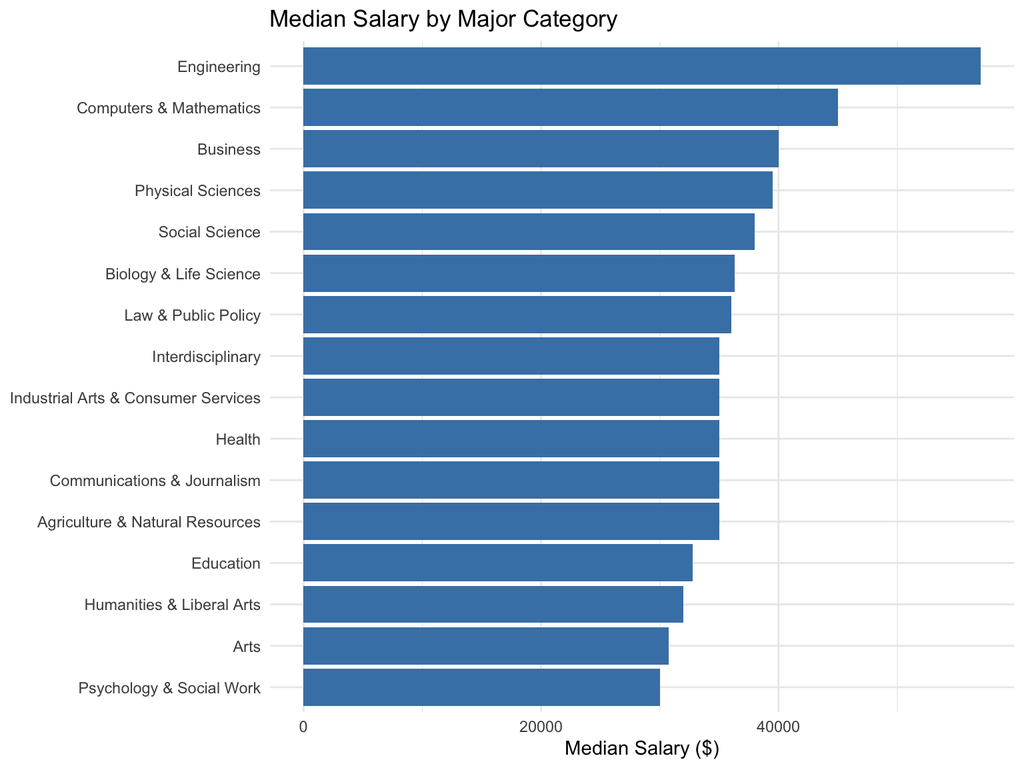

```r
ggplot(category_summary, aes(x = reorder(major_category, median_salary),
                              y = median_salary)) +
  geom_col(fill = "steelblue") +
  coord_flip() +
  labs(
    title = "Median Salary by Major Category",
    x = NULL,
    y = "Median Salary ($)"
  ) +
  theme_minimal()
```

### Scatter plot – Salary vs. unemployment rate

Each point is one major. `geom_smooth()` overlays a LOESS trend line so we can see whether higher-paying majors tend to have lower unemployment.

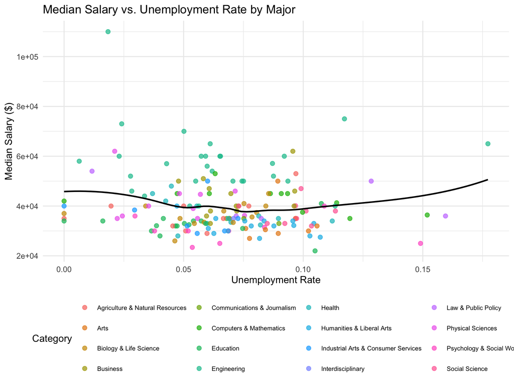

```r
ggplot(major_earnings, aes(x = unemployment_rate, y = median)) +
  geom_point(aes(color = major_category), alpha = 0.7, size = 2) +
  geom_smooth(method = "loess", se = FALSE, color = "black", linewidth = 0.8) +
  labs(
    title = "Median Salary vs. Unemployment Rate by Major",
    x = "Unemployment Rate",
    y = "Median Salary ($)",
    color = "Category"
  ) +
  theme_minimal() +
  theme(legend.position = "bottom",
        legend.text = element_text(size = 7))
```

### Box plot – Salary distributions within categories

Box plots reveal the spread and outliers within each category, not just the center.

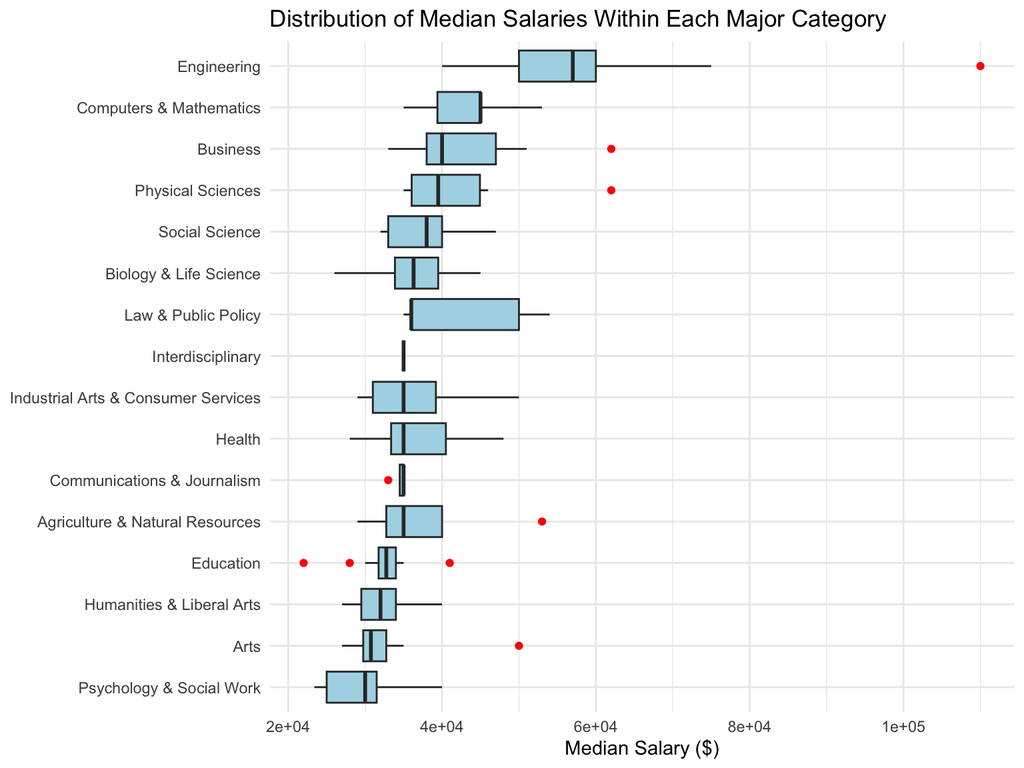

```r
ggplot(major_earnings, aes(x = reorder(major_category, median, FUN = stats::median),
                            y = median)) +
  geom_boxplot(fill = "lightblue", outlier.color = "red") +
  coord_flip() +
  labs(
    title = "Distribution of Median Salaries Within Each Major Category",
    x = NULL,
    y = "Median Salary ($)"
  ) +
  theme_minimal()
```

## Part 3: tidyr – Reshaping Data

### pivot_longer() – Wide to long format

Many ggplot geometries work best with “long” data, where each row is a single observation. The salary percentile columns (`p25th`, `median`, `p75th`) are currently spread across three columns. `pivot_longer()` stacks them into one column so we can map the percentile label to color or facet.

```r
top5 <- major_earnings |>
  arrange(desc(median)) |>
  head(5)

top5_long <- top5 |>
  select(major, p25th, median, p75th) |>
  pivot_longer(
    cols      = c(p25th, median, p75th),
    names_to  = "percentile",
    values_to = "salary"
  )

top5_long
```

```
## # A tibble: 15 × 3
##    major                                     percentile salary
##    <chr>                                     <chr>       <dbl>
##  1 Petroleum Engineering                     p25th       95000
##  2 Petroleum Engineering                     median     110000
##  3 Petroleum Engineering                     p75th      125000
##  4 Mining And Mineral Engineering            p25th       55000
##  5 Mining And Mineral Engineering            median      75000
##  6 Mining And Mineral Engineering            p75th       90000
##  7 Metallurgical Engineering                 p25th       50000
##  8 Metallurgical Engineering                 median      73000
##  9 Metallurgical Engineering                 p75th      105000
## 10 Naval Architecture And Marine Engineering p25th       43000
## 11 Naval Architecture And Marine Engineering median      70000
## 12 Naval Architecture And Marine Engineering p75th       80000
## 13 Chemical Engineering                      p25th       50000
## 14 Chemical Engineering                      median      65000
## 15 Chemical Engineering                      p75th       75000
```

### Visualizing the reshaped data

Now that we have long-format data, a grouped bar chart comparing the three percentiles for each major is straightforward.

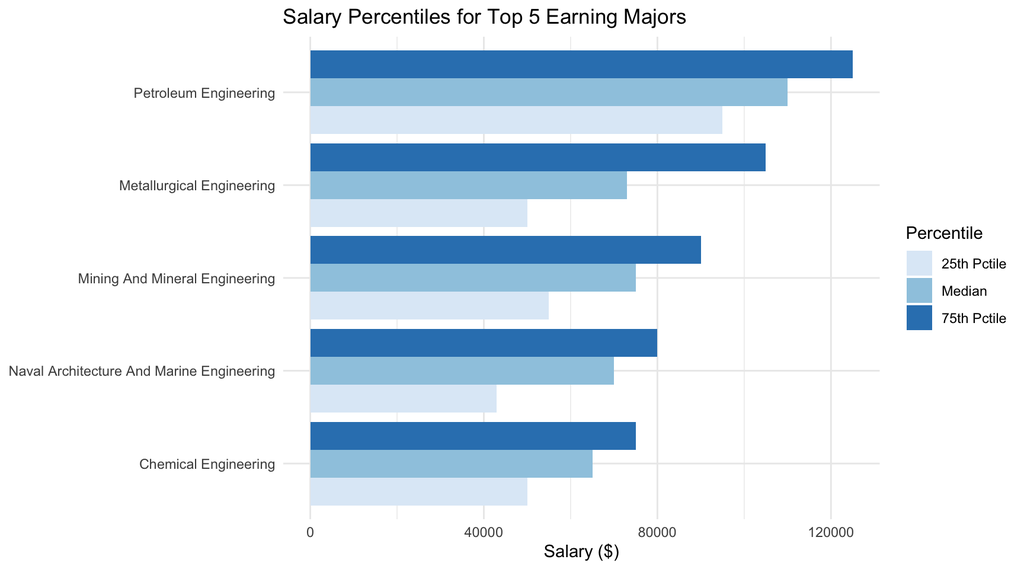

```r
top5_long <- top5_long |>
  mutate(percentile = factor(percentile,
                             levels = c("p25th", "median", "p75th"),
                             labels = c("25th Pctile", "Median", "75th Pctile")))

ggplot(top5_long, aes(x = reorder(major, salary), y = salary, fill = percentile)) +
  geom_col(position = "dodge") +
  coord_flip() +
  scale_fill_brewer(palette = "Blues") +
  labs(
    title = "Salary Percentiles for Top 5 Earning Majors",
    x = NULL,
    y = "Salary ($)",
    fill = "Percentile"
  ) +
  theme_minimal()
```

### pivot_wider() – Long back to wide

`pivot_wider()` is the inverse operation. If a downstream model or table expects one column per percentile, you can spread the data back out.

```r
top5_wide <- top5_long |>
  pivot_wider(
    names_from  = percentile,
    values_from = salary
  )

top5_wide
```

```
## # A tibble: 5 × 4
##   major                                     `25th Pctile` Median `75th Pctile`
##   <chr>                                             <dbl>  <dbl>         <dbl>
## 1 Petroleum Engineering                             95000 110000        125000
## 2 Mining And Mineral Engineering                    55000  75000         90000
## 3 Metallurgical Engineering                         50000  73000        105000
## 4 Naval Architecture And Marine Engineering         43000  70000         80000
## 5 Chemical Engineering                              50000  65000         75000
```

## Conclusion

This vignette walked through the core verbs of three TidyVerse packages:

- **dplyr**: `select()`, `filter()`, `mutate()`, `group_by()`, `summarize()`, `arrange()`
- **ggplot2**: `geom_col()`, `geom_point()`, `geom_smooth()`, `geom_boxplot()`
- **tidyr**: `pivot_longer()`, `pivot_wider()`

Together these tools cover a typical analysis workflow: subset and transform the data, compute summaries, reshape for plotting, and visualize the results.